# Week 3, differential expression

Ane Kleiven

2024-09-19

### Answers to questions **1. What is the general idea behind variance adjustment methods when testing for differential expression? Explain the method and why it is acceptable to use adjustment.** The idea in variance adjustment is to remove the technical variance between the replicates by adjusting the variance towards the mean variance. Some genes may have high biological variance, but the technical variance should be the same. When testing for differential expressions, one would often use few replicates. These replicates often have quite high variance which will affect the statistical significance of the differential expression. By stabilizing the variance across different samples, you make statistical comparisons more significant and reliable. In variance adjustment, you make the variances more similar by moving the individual variances towards the mean variance. The method used for doing this is T-test. Either as a simple T-test, or as linear regression. When doing the T-test, you will get a p-value which tells you whether the data is statistically significant or not. The p-value is affected by the variance. High variance will give a higher p-value. **2. Describe the main differences between finding differentially expressed genes from microarray data and RNA-Seq data.** The microarray data are based on normally distributed data (continuous distribution), while the RNA-seq data are based on counts data. Counts data follows a discrete distribution, of the Poisson. Poisson distribution is shown to underestimate variance in highly expresses genes, therefore you often use negative binomial distribution for finding differentially expressed genes in count data. In normally distributed data you use the T-test to find the DEGs. The different statistical tests used for the different data types, have shown that the negative binomial tests give higher power for highly expressed genes. Normally distributed data doesn’t have this property. The normally distributed data are much more depending on the number of replicates when finding differentially expressed genes. They show a huge difference in results between 2 and 3 replicates (Limma). In the negative binomial methods (DESeq and EDGEr) detected almost all DEGs with both 5% of all the reads and 100% of all the reads. **3. What is (1) function enrichment analysis and (2) gene set enrichment analysis? Explain each method first and then discuss similarities and differences.** Function enrichment analysis looks at genes and gene function. The idea is that you use a controlled vocabulary (gene ontology terms) and see what genes in your list of DEGs are linked to one of these terms in the vocabulary. For example: is the term blood coagulation enriched in the DEGs. In gene set enrichment analysis, you want to find out what genes are enriched at the top of the list of all genes sorted by DE. You have two conditions, phenotype A and B. You sort all the genes after how DE they are. You use a gene set and see what genes (for example genes in blood coaculation) are overrepresented (enriched) in the two conditions. You walk from the top of the list of DE and down. In the function enrichment analysis, you have a list of significant DEGs, while in the gene set enrichment analysis you sort the genes after how DE they are – but they don’t need to be significantly DEGs. No need for any individual gene to be DE. Look at DE as a group. In both analyses you can find about gene function.

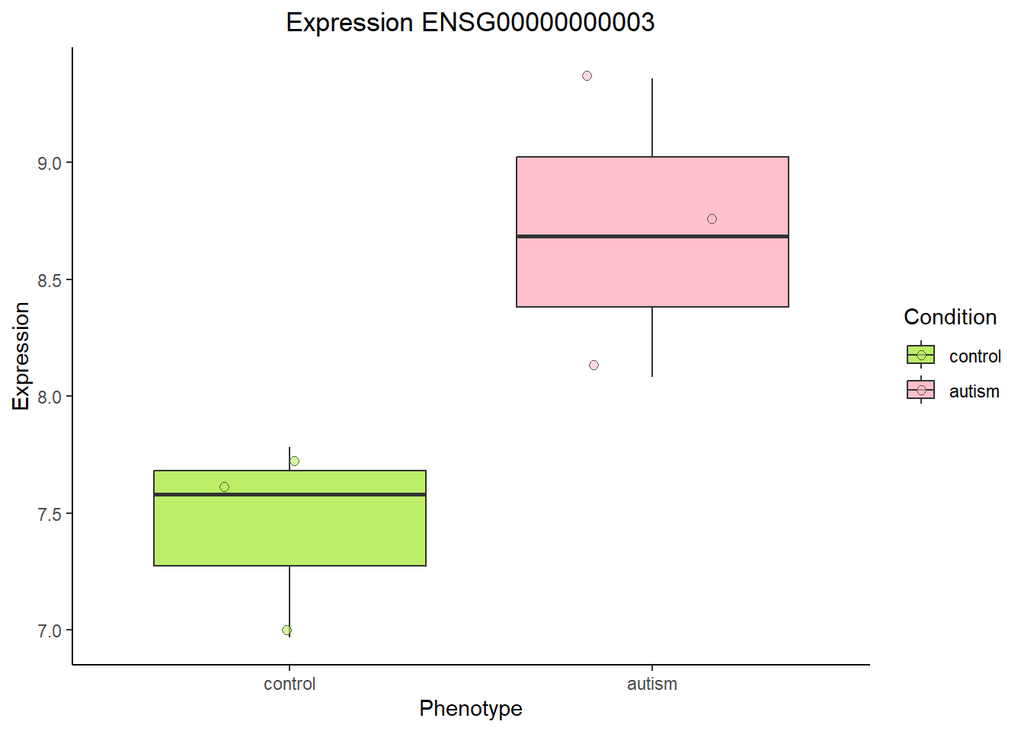

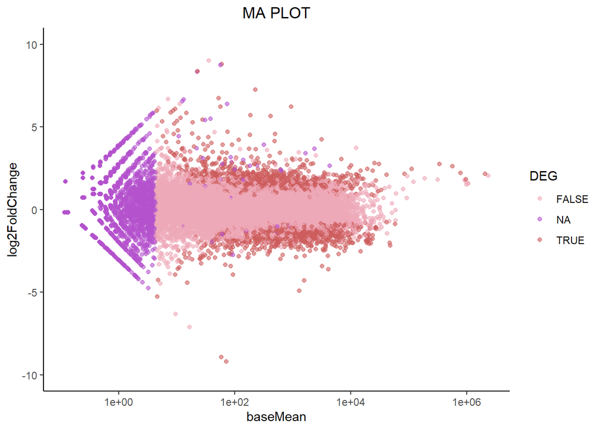

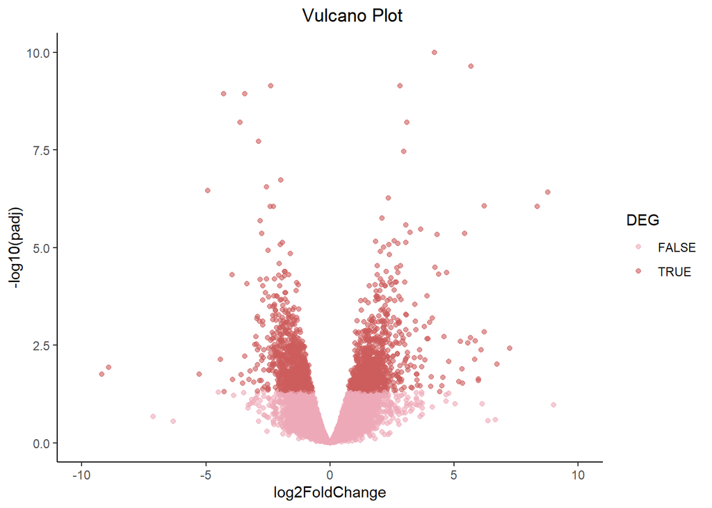

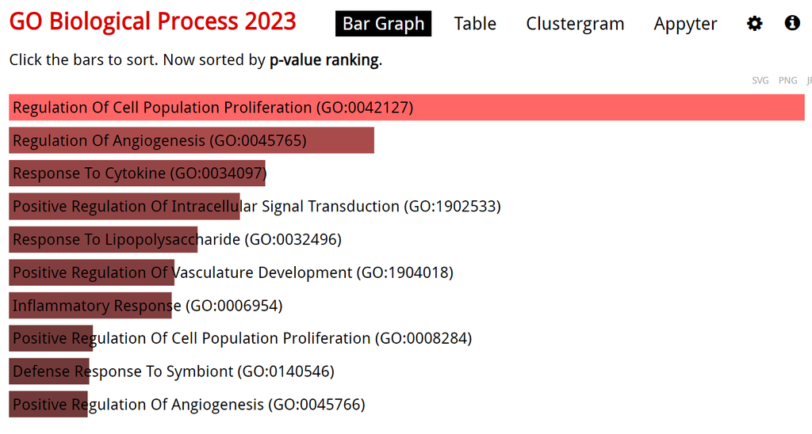

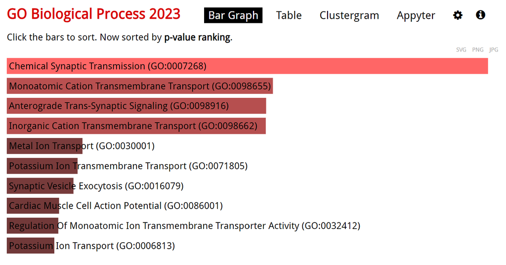